# Part II - Effects of House Features on Their Prices

## by Abdulwasiu Abdulraheem

## Investigation Overview

In this investigation, I wanted to look at the features of houses that could be used to predict their prices. The main focus was on the square footage of the home.

## Dataset Overview

This dataset conatined house sale prices for King County. It consisted of prices and attributes of approximately 21,600 house sales data. The attributes included square footage of the home, grade, waterfront and overall condition as well as additional attributes such as bedrooms, bathrooms and floor.

## Distribution of House Prices

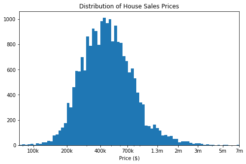

## Distribution of The Square Footages

The square footage of a home is the measurement of amount of space that covers the living area of the house as separated from square footage of the lot and square footage of the basement. The square footage of a typical home in King County lies between 1000 and 2500 square feet.

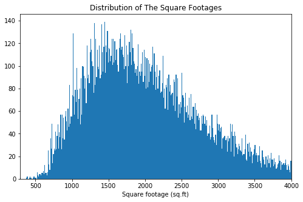

## Price vs. Square Footage

Plotting price and square footage on a logarithmic scale produces an approximately linear relationship. There's a positive relationship between price and the square footage of the home: the higher the size of the footage of a house, the higher the price.

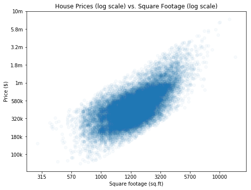